# Projekt - Havaj

### **PART A - úvod**

V tomto projekte budem pracovať s dátami 50. štátu USA - Havaj. Dáta sú časový rád s počiatkom v roku 1900, jednotkovou frekvenciou a koncom v roku 2020. Pre každý rok sledujeme objem zahraničných obchodov v dolároch.

```r
load("NLucic_SIHTD_Continuous_Foreign_Trade_series_1900-2021-14032024.Rdata")
class(x)
```

```
[1] "data.frame"
```

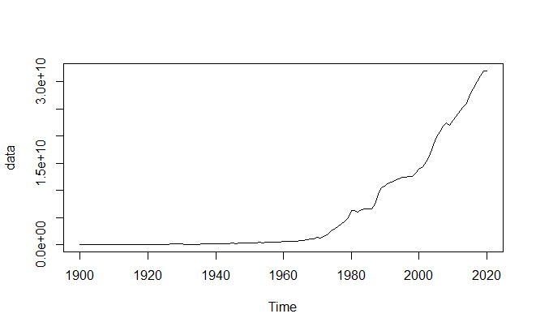

```r
data <- x$Hawaii
na_value_idx <- max(which(!is.na(data)))
years <- x$Years[1:na_value_idx]
start_year <- min(years)
end_year <- max(years)
data <- ts(data[1:na_value_idx], start=start_year, end=end_year)

plot(data)
```

Dáta sú rastúce a s nimi aj ich disperzia, preto dáta logaritmizujeme:

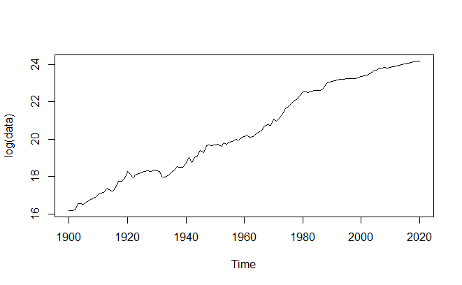

```r
plot(log(data))
```

V dátach môžme pozorovať rastúci trend, preto s istotou môžme povedať, že nie sú stacionárne a kvôli tomu ich zdiferencujeme:

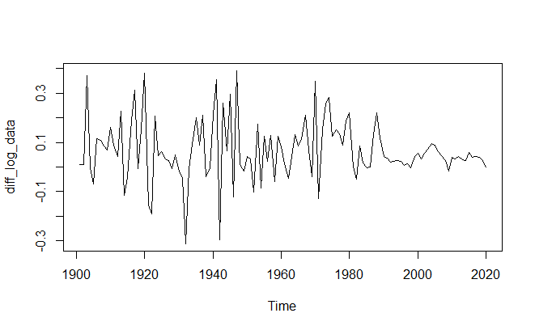

```r
diff_log_data <- diff(log(data))
plot(diff_log_data)
```

### **PART B - testovanie bieleho šumu**

V tejto časti projektu zisťujem či diferencie logaritmizovaných dát sú, resp. nie sú biely šum. K tomu aby boli biely šum musí byť splnených niekoľko podmienok:

1. Proces musí mať nulovú strednú hodnotu,
2. Proces musí mať konštantnú disperziu,
3. Dva rozdielne procesy musia mať nulovú kovarianciu.

Či ide o biely šum sa môžme dozvedieť napríklad vykonaním autokorelácie alebo Ljung-Boxovým testom.

Začnime autokoreláciou:

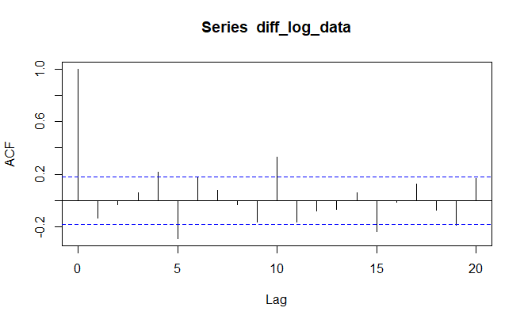

```r
acf(diff_log_data)
```

Graf autokorelačnej funkcie zobrazuje závislosť časového radu po diferenciácii na jednotlivých lagoch. Funkcia acf vypočíta autokorelácie časového radu na jednotlivých lagoch a vizualizuje ich. Ak hodnota autokorelácie prekročí modré prerušené čiary (95 percentné intervaly spoľahlivosti), môže to naznačovať štatisticky významnú závilosť v dátach na danom lag-u. Z grafu vidíme, že na lagoch 4, 5, 10 a 15 autokorelácia prekračuje hranicu spoľahlivosti. Na ostatných lagoch sa hodnoty pohybujú v rámci intervalov spoľahlivosti, a preto nenaznačujú žiadnu štatisticky významnú závislosť. Pozorujeme, že pre lagy, ktoré sú násobky piatich je podľa ACF prítomná štatisticky významná autokorelácia. Zrejme nepôjde o náhodu, domnievam sa, že v dátach stále je nejaká štruktúra a že nejde o biely šum.

Vykonáme Ljung-Boxov test nech sme si istejší:

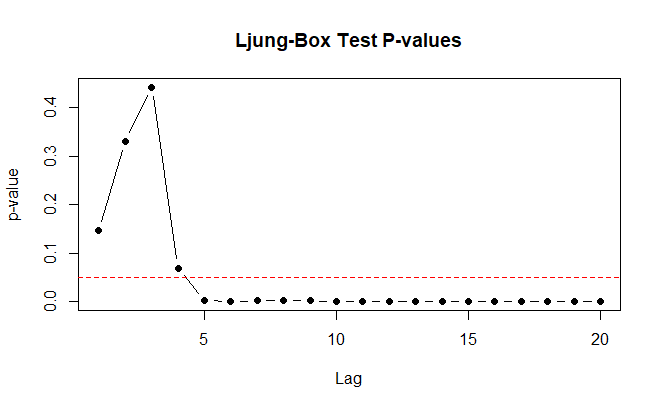

```r
p_values <- numeric(20)

for (lag in 1:20) {
  test_result <- Box.test(diff_log_data, lag = lag, type = "Ljung-Box")
  p_values[lag] <- test_result$p.value
}

plot(1:20, p_values, type = "b", pch = 19, xlab = "Lag", ylab = "p-value",
     main = "Ljung-Box Test P-values", col = "black")
abline(h = 0.05, col = "red", lty = 2)
```

Môžme vidieť, že pre hodnoty lag > 4 sú p hodnoty nižšie ako hranica 0.05 - to znamená, že jednotlivé Ljung-Boxové testy zamietli nulovú hypotézu a prijali alternatívnu hypotézu a teda, že časový rad vykazuje autokorelácie. Záver, ktorý z toho možno odvodiť je, že diferencované logaritmizované dáta nie sú biely šum, nakoľko je prítomná štatisticky významná závislosť. Okrem toho ani stredná hodnota reziduí nebude nulová nakoľko, v logaritmizovaných dátach je stále zachovaný rastúci trend pôvodných dát a tým pádom stredná hodnota diferencií by mala byť kladná.

### **PART C - Funkcia auto.arima**

Najlepší model podľa BIC:

```r
library(forecast)
best_model <- auto.arima(log(data), d = 1, stepwise = FALSE, approximation = FALSE, ic = "bic")
best_model
```

```
Series: log(data)
ARIMA(0,1,0) with drift

Coefficients:
       drift
      0.0667
s.e.  0.0111

sigma^2 = 0.01479:  log likelihood = 83.06
AIC=-162.13   AICc=-162.03   BIC=-156.55
```

Porovnamé s odhadom modelu pomocou funkcie `sarima` z balíka `astsa` s parametrami ARIMA(0,1,0) a zahrnutím driftu

```
<><><><><><><><><><><><><><>

Coefficients:
         Estimate     SE t.value p.value
constant   0.0667 0.0111  6.0349       0

sigma^2 estimated as 0.01466523 on 119 degrees of freedom

AIC = -1.351065  AICc = -1.350783  BIC = -1.304607
```

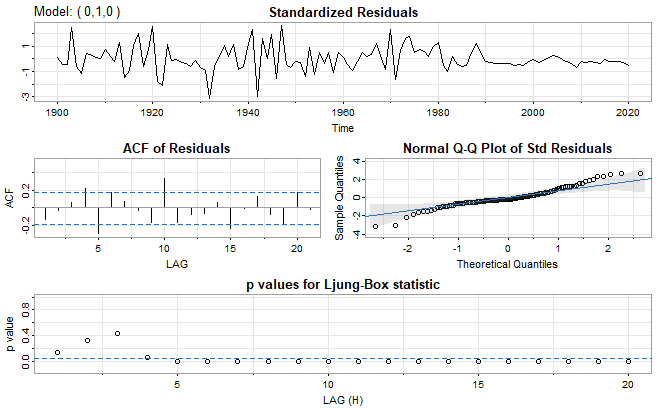

```r
library(astsa)
sarima(log(data), p = 0, d = 1, q = 0, no.constant = FALSE)
```

Výsledky potvrdili rovnakú štruktúru ako pri predchádzajúcom odhade pomocou funkcie `auto.arima`. Rovnica pre odhadnutý model vyjadrená na úrovni diferencií je nasledovná:

$$\Delta \log(data_t) = 0.0667 + \epsilon_t$$

kde 0.0667 je odhadnutý drift a $\epsilon_t$ predstavujú rezíduá modelu.

Rezíduá modelu boli analyzované pomocou ACF rezíduí, Ljung-Boxovho testu a Q-Q grafu. Môžme pozorovať, že ACF naznačuje signifikantnú autokoreláciu pre lagy 4,5,10,15. Opäť teda pozorujeme vzor násobkov piatich čo vzbudzuje podozrenie, že reziduá nie sú biely šum.

Z Q-Q plotu ďalej vidíme, že rezíduá boli približne normálne rozdelené, čo potvrdzuje platnosť predpokladov modelu a má zmysel na nich robiť Ljung-Boxov test.

Ljung-Boxov test odhalil štatisticky významnú autokoreláciu pre hodnoty lagu väčšie ako 4. Na základe výsledkov Ljung-Boxového testu môžme definiívne výlučíť, že reziduá sú biely šum nakoľko je prítomná štatisticky významná závislosť.

Konštantný člen v modeli diferencií (c=0.0667) vyjadruje systematický trend rastu v sérii logaritmicky transformovaných dát. Zachytáva priemerný rast v diferenciách, ktorý súvisí s exponenciálnym charakterom pôvodného nediferencovaného časového radu. Prítomnosť konštanty v modeli teda reflektuje rastúci trend v pôvodných dátach a je nevyhnutná na správne popísanie procesu.

### **PART D - ARIMA modely**

Prejdeme znova všetky modely uvažované pri použití funkcie `auto.arima`.

```r
trace_output <- capture.output(
  auto.arima(log(data), d = 1, stepwise = FALSE, approximation = FALSE, ic = "bic", trace = TRUE)
)

models_bic <- data.frame(Model = character(), BIC = numeric())

for (line in trace_output) {
  if (grepl(": ", line)) {
    model <- sub(":.*", "", line)
    model <- trimws(model)

    bic <- as.numeric(sub(".*: ", "", line))

    models_bic <- rbind(models_bic, data.frame(Model = model, BIC = bic))
  }
}
```

Všetky modely, ktoré funkcia auto.arima brala do úvahy spolu s ich BIC:

```r
models_bic
```

| Model | BIC |
| --- | --- |
| ARIMA(0,1,0) | -129.5322 |
| ARIMA(0,1,0) with drift | -156.5528 |
| ARIMA(0,1,1) | -126.3184 |
| ARIMA(0,1,1) with drift | -153.9486 |
| ARIMA(0,1,2) | -123.6991 |
| ARIMA(0,1,2) with drift | -149.1616 |
| ARIMA(0,1,3) | -125.4006 |
| ARIMA(0,1,3) with drift | -145.5796 |
| ARIMA(0,1,4) | -131.9451 |
| ARIMA(0,1,4) with drift | -144.4745 |

[output cut: 35 more lines]

Na základe hodnoty BIC bol ako najlepší vybraný model **ARIMA(0,1,0) s driftom**, ktorý dosiahol najnižšiu hodnotu BIC (-156.5528), čo naznačuje jeho preferovanosť pred ostatnými modelmi.

Prítomnosť driftu v modeli je odôvodnená priebehom pôvodných nediferencovaných dát, ktoré vykazujú rastúci trend. Bez driftu by model ignoroval tento aspekt dát, čo by mohlo viesť k menej presným predikciám. Reziduá **ARIMA(0,1,0) s driftom** avšak neprešli Ljung-Boxovým a teda ho nepovažujeme v tomto projekte za “dobrý model”. Za “dobrý model” považujeme taký, pre ktorý sú p-hodnoty Ljung-Boxovho testu pre všetky počty korelácií - od minimálneho po maximálny uvažovaný pri použití funkcie `sarima` - väčšie ako 0,05.

```r
library(astsa)
library(forecast)

models_to_test <- list(
  list(p = 0, d = 1, q = 0, drift = FALSE),   # ARIMA(0, 1, 0)
  list(p = 0, d = 1, q = 0, drift = TRUE),    # ARIMA(0, 1, 0) with drift
  list(p = 0, d = 1, q = 1, drift = FALSE),   # ARIMA(0, 1, 1)
  list(p = 0, d = 1, q = 1, drift = TRUE),    # ARIMA(0, 1, 1) with drift
  list(p = 0, d = 1, q = 2, drift = FALSE),   # ARIMA(0, 1, 2)
  list(p = 0, d = 1, q = 2, drift = TRUE),    # ARIMA(0, 1, 2) with drift
  list(p = 0, d = 1, q = 3, drift = FALSE),   # ARIMA(0, 1, 3)
  list(p = 0, d = 1, q = 3, drift = TRUE),    # ARIMA(0, 1, 3) with drift
  list(p = 0, d = 1, q = 4, drift = FALSE),   # ARIMA(0, 1, 4)
  list(p = 0, d = 1, q = 4, drift = TRUE),    # ARIMA(0, 1, 4) with drift
  list(p = 0, d = 1, q = 5, drift = FALSE),   # ARIMA(0, 1, 5)
  list(p = 0, d = 1, q = 5, drift = TRUE),    # ARIMA(0, 1, 5) with drift
  list(p = 1, d = 1, q = 0, drift = FALSE),   # ARIMA(1, 1, 0)
  list(p = 1, d = 1, q = 0, drift = TRUE),    # ARIMA(1, 1, 0) with drift
  list(p = 1, d = 1, q = 1, drift = TRUE),    # ARIMA(1, 1, 1) with drift
  list(p = 1, d = 1, q = 2, drift = TRUE),    # ARIMA(1, 1, 2) with drift
  list(p = 1, d = 1, q = 3, drift = TRUE),    # ARIMA(1, 1, 3) with drift
  list(p = 1, d = 1, q = 4, drift = FALSE),   # ARIMA(1, 1, 4)
  list(p = 1, d = 1, q = 4, drift = TRUE),    # ARIMA(1, 1, 4) with drift
  list(p = 2, d = 1, q = 0, drift = FALSE),   # ARIMA(2, 1, 0)
  list(p = 2, d = 1, q = 0, drift = TRUE),    # ARIMA(2, 1, 0) with drift
  list(p = 2, d = 1, q = 1, drift = TRUE),    # ARIMA(2, 1, 1) with drift
  list(p = 2, d = 1, q = 3, drift = FALSE),   # ARIMA(3, 1, 0)
  list(p = 3, d = 1, q = 0, drift = FALSE),   # ARIMA(3, 1, 0)
  list(p = 3, d = 1, q = 0, drift = TRUE),    # ARIMA(3, 1, 0) with drift
  list(p = 3, d = 1, q = 1, drift = TRUE),    # ARIMA(3, 1, 1) with drift
  list(p = 4, d = 1, q = 0, drift = FALSE),   # ARIMA(4, 1, 0)
  list(p = 4, d = 1, q = 0, drift = TRUE),    # ARIMA(4, 1, 0) with drift
  list(p = 4, d = 1, q = 1, drift = FALSE),   # ARIMA(4, 1, 1)
  list(p = 4, d = 1, q = 1, drift = TRUE),    # ARIMA(4, 1, 1) with drift
  list(p = 5, d = 1, q = 0, drift = FALSE),   # ARIMA(5, 1, 0)
  list(p = 5, d = 1, q = 0, drift = TRUE)     # ARIMA(5, 1, 0) with drift
)

good_models <- list()

for (model in models_to_test) {
  p <- model$p
  d <- model$d
  q <- model$q
  drift <- model$drift

  #cat("\nVyhodnotenie modelu ARIMA(", p, ", ", d, ", ", q, ifelse(drift, " with drift", ""), ")\n")

  if (drift) {
    fitted_model <- Arima(log(data), order = c(p, d, q), include.drift = TRUE)
  } else {
    fitted_model <- Arima(log(data), order = c(p, d, q), include.drift = FALSE)
  }

  residuals <- residuals(fitted_model)

  p_values <- sapply(1:20, function(lag) {
    Box.test(residuals, lag = lag, type = "Ljung-Box")$p.value
  })

  if (all(p_values > 0.05)) {
    good_models <- append(good_models, list(list(model = paste("ARIMA(", p, ", ", d, ", ", q, ifelse(drift, " with drift", ""), ")"), BIC = fitted_model$bic)))
  }
}
```

Všetky dobré modely:

```r
good_models_df <- do.call(rbind, lapply(good_models, as.data.frame))
sorted_good_models_df <- good_models_df[order(as.numeric(good_models_df$BIC)), ]
print(sorted_good_models_df)
```

|  | model | BIC |
| --- | --- | --- |
| 3 | ARIMA( 4 , 1 , 1 with drift ) | -150.4740 |
| 5 | ARIMA( 5 , 1 , 0 with drift ) | -150.1727 |
| 1 | ARIMA( 1 , 1 , 4 with drift ) | -147.6846 |
| 2 | ARIMA( 4 , 1 , 1 ) | -141.2750 |
| 4 | ARIMA( 5 , 1 , 0 ) | -138.3777 |

Najlepší model:

```
<><><><><><><><><><><><><><>

Coefficients:
         Estimate     SE t.value p.value
ar1       -0.7549 0.1557 -4.8496  0.0000
ar2       -0.1122 0.1117 -1.0047  0.3172
ar3        0.0713 0.1121  0.6355  0.5264
ar4        0.3002 0.0944  3.1814  0.0019
ma1        0.6898 0.1499  4.6013  0.0000
constant   0.0671 0.0115  5.8354  0.0000

sigma^2 estimated as 0.01257097 on 114 degrees of freedom

AIC = -1.416553  AICc = -1.410359  BIC = -1.25395
```

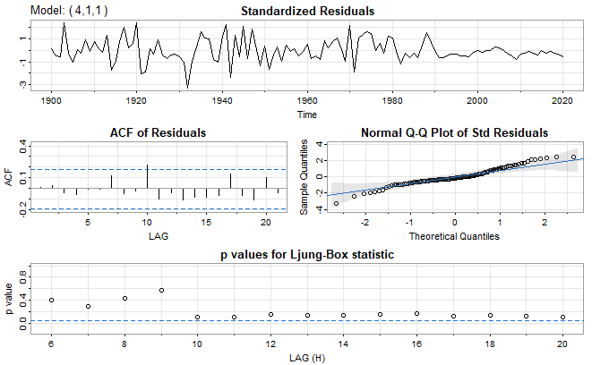

```r
library(astsa)
sarima(log(data), p = 4, d = 1, q = 1, no.constant = FALSE)
```

ACF naznačuje štatisticky významnú autokoreláciu pre lag rovný 10 a podľa Q-Q grafu sa reziduá javia byť približne normálne. Ljung-Boxov test nezamietol nulovú hypotézu pre ani jednu s otestovaných hodnôt lagu a v reziduách nie je prítomná štatisticky významná závislosť a reziduá môžme považovať za biely šum.

Rovnica odhadnutého modelu ARIMA(4,1,1) s driftom je nasledovná:

$$ \Delta \log(data_t) = 0.0671 - 0.7549 \Delta \log(data_{t-1}) - 0.1122 \Delta \log(data_{t-2}) + 0.0713 \Delta \log(data_{t-3}) + 0.3002 \Delta \log(data_{t-4}) + 0.6898 \epsilon_{t-1} + \epsilon_t, $$

### **PART E - Unit Root Test**

Parametre použitého Unit Root testu:

1. **Typ regresie**: `type = "drift"`. Chceme aby regresia obsahovala drift (konštantný člen), nakoľko dáta majú rastúci trend.
2. **Počet lagov**: `lags = 20`, pričom optimálny počet lagov bol zvolený na základe kritéria BIC (`selectlags = "BIC"`). Lagy sa pridávajú, aby sa eliminovala autokorelácia rezíduí.

```r
library(urca)
summary(ur.df(diff_log_data, type = "drift", lags = 20, selectlags = "BIC"))
```

```
###############################################
# Augmented Dickey-Fuller Test Unit Root Test #
###############################################

Test regression drift


Call:
lm(formula = z.diff ~ z.lag.1 + 1 + z.diff.lag)

Residuals:
     Min       1Q   Median       3Q      Max
-0.37959 -0.05157 -0.02100  0.04928  0.31087

Coefficients:
            Estimate Std. Error t value Pr(>|t|)
(Intercept)  0.06365    0.01489   4.275 4.51e-05 ***
z.lag.1     -1.04215    0.15049  -6.925 4.94e-10 ***
z.diff.lag  -0.05531    0.09731  -0.568    0.571
---
Signif. codes:  0 ‘***’ 0.001 ‘**’ 0.01 ‘*’ 0.05 ‘.’ 0.1 ‘ ’ 1

Residual standard error: 0.116 on 96 degrees of freedom
Multiple R-squared:  0.5626,    Adjusted R-squared:  0.5535
F-statistic: 61.73 on 2 and 96 DF,  p-value: < 2.2e-16


Value of test-statistic is: -6.925 23.9784

Critical values for test statistics:
      1pct  5pct 10pct
tau2 -3.46 -2.88 -2.57
phi1  6.52  4.63  3.81
```

Testované hypotézy:

- **Nulová hypotéza**: Časový rad má jednotkový koreň (nie je stacionárny).
- **Alternatívna hypotéza**: Časový rad nemá jednotkový koreň (je stacionárny).

Na základe výsledku testu môžeme zamietnuť nulovú hypotézu o jednotkovom koreni s vysokou štatistickou istotou (p<0.001). Diferencie logaritmov sú stacionárne, čo znamená, že ďalšie diferencovanie nebolo potrebné.

### **PART F - Predikcie**

Na základe historických dát predikujeme budúce hodnoty na najbližších 10 rokov:

```
$pred
Time Series:
Start = 2021
End = 2030
Frequency = 1
 [1] 24.26005 24.32122 24.37587 24.43308 24.50941 24.56798 24.63604 24.70107 24.77179 24.83390

$se
Time Series:
Start = 2021
End = 2030
Frequency = 1
 [1] 0.1121203 0.1534876 0.1819731 0.2136243 0.2527861 0.2770216 0.3043622 0.3289528 0.3536188 0.3735888
```

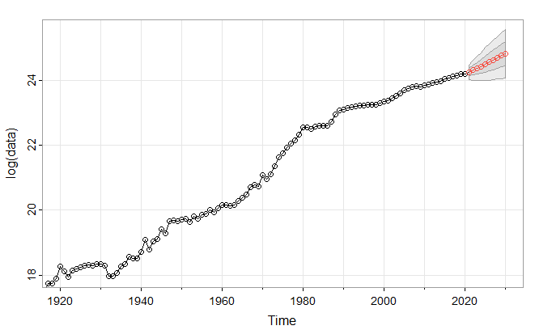

```r
pocet_rokov <- 10

sarima.for(log(data), n.ahead = pocet_rokov, p = 4, d = 1, q = 1)
```

Predikcia na nasledujúcich 10 rokov ukazuje pokračujúci rast, ktorý je teda v súlade s doterajším trendom pozorovaným v historických dátach. Model očakáva, že trend bude pretrvávať bez výrazných zmien alebo odchýlok, čo naznačuje, že správanie časového radu ostáva konzistentné s doterajšou históriou. Šedé intervaly spoľahlivosti okolo predikovaných hodnôt sa postupne rozširujú, čo je prirodzené, pretože neistota predikcie narastá so zvyšujúcim sa časovým horizontom.